# Model fitting: worked solutions

PCB 6455 / BSC 4933: Biometry | Lecture 19

Dr. Brian Maitner

## How to use this

The code from Lecture 19, run, with the numbers it produces, plus two follow-ups the slides only mention.

Times depend on your computer, so yours will differ. Everything else should match to three or four decimals.

## Setting up

```r
library(bbmle)

occ <- read.csv("https://github.com/bmaitner/biometry_course/raw/refs/heads/main/data/class_examples/bobwhite_occupancy.csv")

occ_nll <- function(p){
  prob <- plogis(p[1] + p[2] * occ$elapsed)
  -sum(dbinom(occ$n_occupied, size = occ$n_routes, prob = prob, log = TRUE))
}

occ_nll(c(2, -0.05))
```

```
[1] 59.80241
```

With the course package installed, `occ <- bobwhite_occupancy` gives the same table.

## Brute force

```r
a_vec <- seq(1, 3, by = 0.01)
b_vec <- seq(-0.15, 0.05, by = 0.001)
grid <- expand.grid(a = a_vec, b = b_vec)
nrow(grid)
```

```
[1] 40401
```

```r
grid_time <- system.time({
  grid$nll <- NA
  for (i in 1:nrow(grid)) {
    grid$nll[i] <- occ_nll(c(grid$a[i], grid$b[i]))
  }
})
grid_time["elapsed"]
```

```
elapsed
   2.92
```

```r
grid[which.min(grid$nll), ]
```

```
         a      b      nll
17791 2.02 -0.062 56.68828
```

## Two methods

```r
fit_nm   <- optim(c(0, 0), occ_nll)
fit_bfgs <- optim(c(0, 0), occ_nll, method = "BFGS")

rbind(nelder_mead = c(fit_nm$par, nll = fit_nm$value, fit_nm$counts),
      bfgs        = c(fit_bfgs$par, nll = fit_bfgs$value, fit_bfgs$counts))
```

```
                                      nll function gradient
nelder_mead 2.017858 -0.06190033 56.68808       75       NA
bfgs        2.017687 -0.06189783 56.68807       45        9
```

Same answer to three decimals. BFGS needed fewer evaluations of the NLL, plus a few estimates of the slope; Nelder-Mead never computes a slope, hence `NA`.

## Annealing twice

```r
set.seed(1)
fit_sa1 <- optim(c(0, 0), occ_nll, method = "SANN")

set.seed(2026)
fit_sa2 <- optim(c(0, 0), occ_nll, method = "SANN")

rbind(seed_1    = c(fit_sa1$par, nll = fit_sa1$value),
      seed_2026 = c(fit_sa2$par, nll = fit_sa2$value))
```

```
                                    nll
seed_1    2.012366 -0.06167697 56.68933
seed_2026 2.011101 -0.06170355 56.69079
```

Close to BFGS, not identical, and different from each other.

## Follow-up: anneal, then polish

Start BFGS from wherever annealing stopped:

```r
fit_polish <- optim(fit_sa1$par, occ_nll, method = "BFGS")
c(fit_polish$par, nll = fit_polish$value)
```

```
                                nll
 2.01768685 -0.06189783 56.68807288
```

Annealing found the right valley; BFGS found the bottom of it. On surfaces with several dips, this is the standard combination.

## A fit that fails without an error

```r
fit_cg <- optim(c(0, 0), occ_nll, method = "CG")
c(fit_cg$par, nll = fit_cg$value, convergence = fit_cg$convergence)
```

```
                                nll convergence
 1.15421555 -0.00618068 81.52072566  1.00000000
```

`convergence` is 1: it hit its step limit, and its $b$ is ten times too small.

## Follow-up: give it more steps

```r
fit_cg2 <- optim(c(0, 0), occ_nll, method = "CG", control = list(maxit = 10000))
c(fit_cg2$par, nll = fit_cg2$value, convergence = fit_cg2$convergence)
```

```
                                nll convergence
  2.0171815  -0.0618662  56.6880826   0.0000000
```

```r
fit_cg2$counts
```

```
function gradient
    4857      953
```

With enough steps CG gets there, but it needed thousands of evaluations where BFGS needed under a hundred. Raising `maxit` is a fix for a method that was heading the right way; switching method is usually the better one.

## Many starts on the reef hump

```r
reef <- read.csv("https://github.com/bmaitner/biometry_course/raw/refs/heads/main/data/class_examples/reef_surveys.csv")

reef_nll <- function(p){
  mu <- exp(p[1]) * exp(-(reef$depth - p[2])^2 / (2 * exp(p[3])^2))
  -sum(dnbinom(reef$richness, mu = mu, size = exp(p[4]), log = TRUE))
}

set.seed(19)
results <- NULL
for (i in 1:10) {
  start <- c(log(runif(1, 5, 50)), runif(1, 0, 30), log(runif(1, 1, 50)), log(runif(1, 1, 20)))
  fit <- optim(start, reef_nll)
  results <- rbind(results, c(peak = exp(fit$par[1]), depth = fit$par[2],
                              width = exp(fit$par[3]), nll = fit$value,
                              convergence = fit$convergence))
}
round(results, 1)
```

```
      peak depth   width     nll convergence
 [1,] 24.7  16.1    24.2 31752.3           0
 [2,] 23.5   2.8 13416.1 31799.0           0
 [3,] 24.7  16.1    24.2 31752.3           0
 [4,] 24.4  26.0    52.8 31778.7           0
 [5,] 24.7  16.1    24.2 31752.3           0
 [6,] 24.5  31.0    65.9 31782.5           0
 [7,] 24.7  16.1    24.2 31752.3           0
 [8,] 24.7  16.1    24.2 31752.3           0
 [9,] 24.4  23.9    47.0 31775.9           0
[10,] 24.7  16.1    24.2 31752.3           0
```

## What the starts show

Six of ten agree: a peak of about 25 species at about 16 m, with a width of about 24 m. The other four stopped somewhere else, one of them on the plateau, with a width over 13,000 m, which is a flat line.

Every one reports `convergence = 0`. Report the row with the lowest NLL, and treat agreement among the best few as the reassurance.

## Drawing the fit

```r
bins <- cut(reef$depth, breaks = seq(0, 32, by = 2))
plot(tapply(reef$depth, bins, mean), tapply(reef$richness, bins, mean),
     pch = 16, xlab = "depth (m)", ylab = "mean species richness")

hump <- function(d, row){
  results[row, "peak"] * exp(-(d - results[row, "depth"])^2 / (2 * results[row, "width"]^2))
}
best <- which.min(results[, "nll"])
worst <- which.max(results[, "nll"])
curve(hump(x, best), add = TRUE, col = "red", lwd = 3)
curve(hump(x, worst), add = TRUE, col = "grey50", lwd = 3, lty = 2)
```

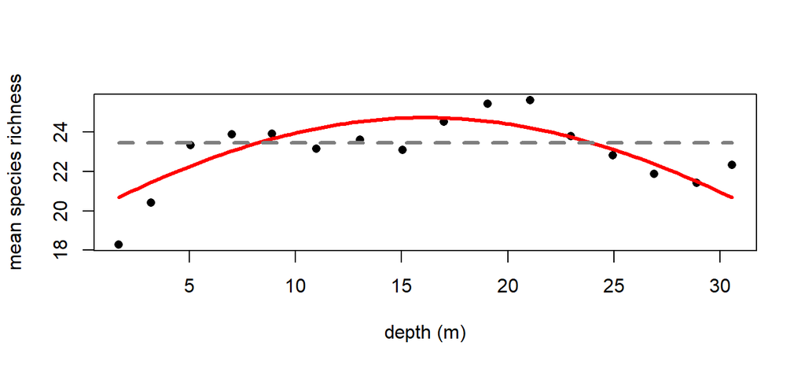

The best fit follows the hump; the worst is a flat line.

## Simulating from the fit

```r
p_fit <- plogis(fit_bfgs$par[1] + fit_bfgs$par[2] * occ$elapsed)

set.seed(1)
fake <- replicate(1000, rbinom(nrow(occ), size = occ$n_routes, prob = p_fit) / occ$n_routes)
lower <- apply(fake, 1, quantile, 0.025)
upper <- apply(fake, 1, quantile, 0.975)

plot(occ$year, occ$n_occupied / occ$n_routes, pch = 16, ylim = c(0.5, 1),
     xlab = "year", ylab = "fraction of routes occupied")
lines(occ$year, lower, lty = 2)
lines(occ$year, upper, lty = 2)
```

```r
obs <- occ$n_occupied / occ$n_routes
sum(obs >= lower & obs <= upper)
```

```
[1] 23
```

[figure not shown]

All 23 years sit inside the band: the model produces data like the real data.

## The challenge

```r
counts <- read.csv("https://github.com/bmaitner/biometry_course/raw/refs/heads/main/data/class_examples/bobwhite_counts.csv")

threshold_nll <- function(p){
  mu <- exp(p[1] + p[2] * pmax(0, counts$frac_built - p[3]))
  -sum(dnbinom(counts$count, mu = mu, size = exp(p[4]), log = TRUE))
}

start <- c(2, -1, 0.3, 0)
first_try <- optim(start, threshold_nll)
c(first_try$par, nll = first_try$value)
```

```
                                                             nll
   2.8269559   -3.2252541   -0.1027432    0.3893916 4574.1480199
```

The threshold ends up below zero: every route is past it, so the threshold does nothing and this is just the plain development model.

## Winning approach 1: keep the threshold inside the data

```r
fit_bounded <- optim(start, threshold_nll, method = "L-BFGS-B",
                     lower = c(-Inf, -Inf, 0, -Inf),
                     upper = c(Inf, Inf, 0.48, Inf))
c(fit_bounded$par, nll = fit_bounded$value)
```

```
                                                                  nll
   2.46859014   -3.38089406    0.01400069    0.39437595 4571.33411293
```

## Winning approach 2: brute force on the threshold alone

```r
t_grid <- seq(0, 0.45, by = 0.005)
t_nll <- sapply(t_grid, function(t){
  optim(c(2.5, -3, 0.4), function(q){ threshold_nll(c(q[1], q[2], t, q[3])) })$value
})
best_t <- t_grid[which.min(t_nll)]
best_t
```

```
[1] 0.015
```

```r
fit_grid <- optim(c(2.5, -3.4, best_t, 0.4), threshold_nll)    # polish
c(fit_grid$par, nll = fit_grid$value)
```

```
                                                                  nll
   2.46776009   -3.36596740    0.01409938    0.39356979 4571.32782283
```

## Winning approach 3: anneal, then polish

```r
set.seed(1)
fit_sa <- optim(start, threshold_nll, method = "SANN")
fit_polish <- optim(fit_sa$par, threshold_nll)
c(fit_polish$par, nll = fit_polish$value)
```

```
                                                                  nll
   2.46783507   -3.37114639    0.01409979    0.39416608 4571.32767954
```

All three reach the same answer: a threshold near 1.4% developed, so counts fall from almost the first development. It beats the plain development model by about 2.8 NLL units for one extra parameter, so AIC prefers it, narrowly.